# Aside

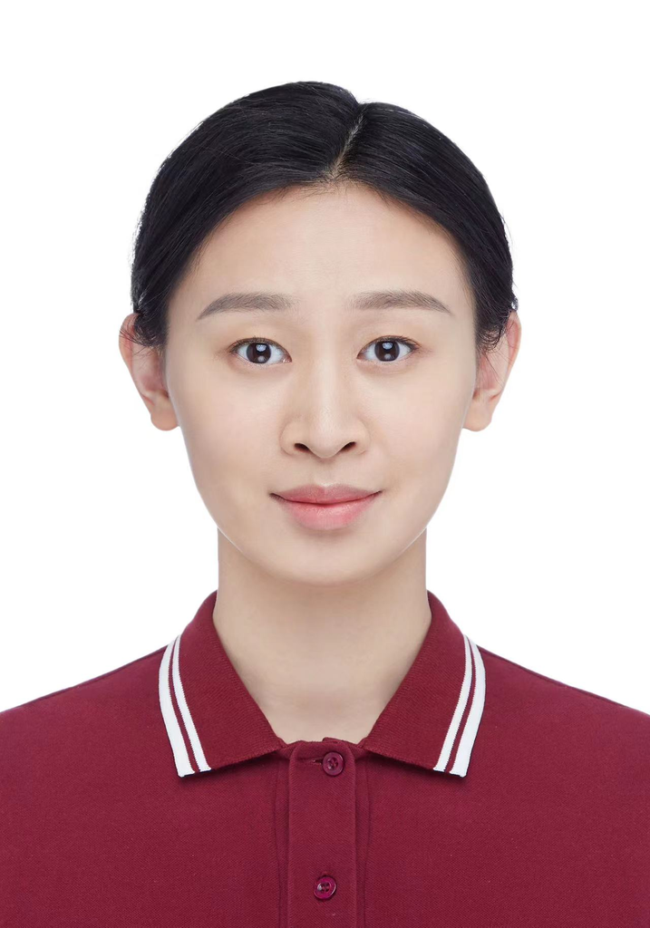

## 联系方式

- 19858360107@163.com
- 198-5836-0107

# Main

## 郑晔

籍贯：浙江丽水  
年龄：1992.10.26  
政治面貌：群众  
双语社会工作者, 能够独立根据工作要求，将方西社会工作理念 和技巧本土化。有着较强的人际交往能力与沟通能力,可以进行简单的商业洽谈, 能够独立代表公司完成资方或者合作方的商业 沟通和商务合作, 精通中英文听说读写。寻求一个能够充分展示我的专业技能，运用海外求学经历和过往工作经验的岗位，对社会工作、公益事业、社区工作、群众工作和政府事务充满热情。同时也对社会主义新时代的商业运营模式和商务洽谈的新思路和新方式充满了好奇并做好了充分的工作准备。本人对祖国的文化和历史有着深厚的人文情怀，对党和政府的执政和政策落实怀抱高度的敬畏和感恩。

## 教育背景

### 硕士：社会工作

明尼苏达大学双城分校

美国，圣保罗

2019 - 2015

- 专业分流：临床心理学及精神健康
- 第二分流：家庭及儿童研究

### 学士：社会工作

浙江树人大学

中国，杭州

2015 - 2011

## 工作经历

### 医务社工

首都医科大学附属北京安定医院

中国，北京

至今 - 2025

- 基于医院内原有的结构框架从社会工作视角为医院的康复治疗、特色活动、社区活动等提供支持与服务；接待前来医患关系协调办投诉和申请诊断复核的患者提供政策解读、流程解答、心理疏导、情感支持与情绪安抚等工作；定期在医院门诊为有需要的患者导诊、解答疑惑、提供技术支持、支持完成异地就医备案等；定期前往医院康复中心在患者康复的过程中提供宏观的社会支持并为有需要的患者提供个案服务或小组服务为患者康复和社会化进程贡献社工力量。

### 一线社工

青田县海潮公益发展中心

中国，丽水

2025 - 2024

- 协助上级完成一些文案工作提交到民政局后根据反馈意见做修改；协助上级完成分发给各残疾人之家和养老中心的报告或规定，形成定稿之后打印成纸质材料，供各机构参考学习；参与各类民间活动，如公益创投大赛演说、重阳节联欢会主持，女性专题讲座主持等；完成常规的点位检查，定期到残疾人之家送餐具、送服务，与此同时对点位做基础的检查和意见反馈；根据上级相关要求，做数据系统录入和统计，包括电子表格制作和居家养老系统网站录入；下乡完成常规工作，如春节送春联、帮助60周岁以上的老年人办理爱心卡等。

### 医务社会工作者

水滴公司—枫林社会工作发展中心

中国，北京

2023 - 2022

- 在北京医科大学首都儿童医院和北京宣武医院完成医务社会工作者的专业日常工作，其中包括每日定期的病房探访项目约2-3小时，完成后根据机构的探访表格做详细的记录和反思总结；面对大病医保在京无法享受优惠政策的案主，开展筹转介工作并依据国情将西方社会工作的理念和技巧本土化，对有需要的案主展开有效有益的个案工作介入，同时将案主同意宣传的相关信息转介给筹顾问，发布在互联网上帮助案主筹集善款并帮助其渡过难关；每月挑选经典有影响力的案主的案例撰写个案工作的经典故事并作有效的案例分析，分享在团队内部与其团队成员共同学习与成长；支持与协助驻科医院的大型节日和活动，根据社会工作的专业技巧和理念，设计每次活动的方案和项目书，与医院的医生和护士共同将相关的项目和活动方案落地，帮助医生和护士开展更好的活动项目和营造良好的医患关系氛围；在公司总部帮助项目总监挑选全国范围内可能实施儿童医务社会项目的医院，同时按照相关的医院实际情况，撰写可以落地的有效项目书；协助项目经理完成全国各地医院的数据核对和修改，确保相关项目的有效进行和数据分析的准确性。

### 就业辅导员

北京市海淀区融爱融乐心智障碍者家庭支持中心

中国，北京

2022 - 2021

- 评估心智障碍青年岗前能力并做出专业分析评定该青年是否有能力上岗就业。在心智障碍青年上岗之后提供专业的密集支持服务，帮助其熟练掌握工作内容和有效运用工作技巧，在心智障碍青年有能力独立完成工作之后，开展专业的跟踪支持，了解该案主的基本情况，最终帮助其实现稳定就业。于此同时，协同团队开展家长就业转衔课，普及融合就业的理念和创造融合就业的氛围，帮助心智障碍群体家长更好地支持和帮助他们的孩子实现稳定就业。协助项目总监完成交付给资方的季报及双月报告的撰写，汇报工作内容、工作进展和工作成效；对接资方媒体传播方向负责人为其提供受益人故事和受益人影像素材；撰写中小型活动项目的项目方案并协助项目总监完成项目书的文字润色修改。设计心智障碍者自倡导活动之自主生活培训营的方案和课件，并独立带领心青年开展课程，完成对每一位心智障碍青年的个性化评估和总结，对接心智障碍者家长为其答疑解惑提供专业的融合就业知识普及和技巧输出。

### 职业咨询师/职业咨询顾问

Task Unlimited, Inc.（非营利组织）

美国，明尼阿波利斯

2020 - 2019

- 为残疾人及精神病人提供职业发展和巩固职业稳定性的咨询服务。与职业咨询测评分析师紧密合作确保为案主建立长期稳定的职业规划。基于案主个人的工作技巧层次和工作经历使用专业的社会工作技巧帮助案主选择和追求合适的工作岗位。帮助案主发展有效的职业培训和雇佣计划。分析案主的自身优势并向他们展示如何有效的在工作中运用这些优势。指导案主在学习过程中完成工作任务。评估对案主的工作培训和工作支持的需要。监督和评估案主的各方面的进步。适时记录工作日志并及时向主管反馈。与案主建立良好的职业关系提供有同理心的和有建设性的反馈。与雇主确认发展并保持有意义的合作伙伴关系为案主创造更多的工作机会。帮助案主修改简历并提出合适的建议。协助案主提交工作申请并为案主提供模拟面试为正式面试作准备。协同案主参与招聘会探索更多的工作机会和提升与雇主交流的沟通技巧

### “ NAVIGATE” 项目职业及教育辅助顾问（实习）

明尼苏达大学双城分校

美国，圣保罗

2019 - 2018

- 支持第一阶段的精神病患者实现教育和职业目标，运用IPS (Individual Placement and Support)模型理论帮助他们生活在一个行为健康的环境中并有能力选择合适自己的职业。在专业支持的条件下开展家访于舒适的环境中支持案主并核对他们的进步情况。与案主家人建立职业合作关系帮助案主学习与亲人和朋友建立健康的亲密关系。探访案主的学校和工作单位在职业环境中确认他们的进步情况并通过培训他们提升职业和学术技巧。评估案主在职业中的优势和仍需提升的地方。参与定期的会议与心理咨询师讨论案主的进步情况和问题。与此同时运用CBT(认知行为疗法),DBT(辩证行为疗法)和自我康复培训理论为案主提供部分心理咨询服务。
- 运用 CBT(感知心理学理论)、DBT(行为心理学理论)和自我康复培训理论为案主提供部分心理咨询服务

### “生命天堂”项目青少年辅导员

路德会社会服务非盈利组织

美国，圣保罗

2018

- 辅导及培训未成年妈妈独立生活的能力，帮助她们建立财务管理能力，增强家务工作技能并培训相关面试技巧，帮助照料未成年妈妈的新生儿和情绪疏导，每天记录相关工作日记并录入机构信息数据库。保护未成年妈妈和孩子的健康和安全。为未成年妈妈提供直接的督导，支持和引导。

### 项目管理员（实习）

”Daily Work“非营利组织

美国，圣保罗

2018 - 2017

- 支持有就业困难的求职者（75%的案主是美国的难民和新移民）进行简历撰写及职业技巧的建立，提供一对一的职业咨询服务提高案主的社交能力和面试技巧，提供求职技巧培训和职业外展训练服务,同时帮助案主提升英文口语和写作技巧。参与定期的督导会议综合分析案主的情况，包括他们的交通，医疗保健和儿童保育等。与其它非赢利组织建立合作关系为案主获得更多的资源。提供模拟面试帮助案主提供面试技巧。发展与案主的信任关系为案主提供有同理心的和有建设性的反馈意见。

## 实习/志愿服务经历

### 人力资源主管（志愿性）

MAZE非盈利组织

美国线上远程工作

至今 - 2019

- 设计面试问题和个案学习案例，为申请者提供电话/视频/语音面试，协调机构内部成员关系，组织机构团队活动加强成员之间的工作关系及情感联系，参与机构项目设计和对外宣传为机构获取更多捐赠与合作的机会

### 儿童阅读辅导员（志愿性）

“学在社区中”非盈利组织

美国，明尼阿波利斯

2017

- 为6到9岁适龄儿童提供以社区为基础的周末阅读辅导服务，回答儿童在阅读中遇到的问题并帮助他们完成周末家庭作业

### 食品免费供应货仓员（志愿性）

CAPI非盈利组织

美国，明尼阿波利斯

2016

- 整理食品货架，装米，封装食物向低收入家庭及人群分发免费食；同年10月参与2016年美国总统大选向市民分发选票的志愿活动
- 参与2016年美国总统大选向市民分发选票的志愿活动

### 实习生

松阳县民政局信访办

中国，丽水

2015

- 接待来访民众并做好相关信息登记工作，定期完成电子录入，并向部门主管学习询问县民政局基础工作并主要深入学习研究信访办的常规工作

## 领导经历

### 人文学院校友部部长

浙江树人大学

中国，杭州

2013 - 2012

### 班级通讯联络员

浙江树人大学

中国，杭州

2012 - 2011

### 社会工作专业英语课代表

浙江树人大学

中国，杭州

## 获奖情况

### 新手恰恰舞二等奖及新手伦巴舞三等奖

明尼苏达州舞蹈节

美国，明尼阿波利斯

2017

### 社会工作先进个人

浙江树人大学

中国，杭州

2012

### 第十二届文化艺术节之“我的信仰”演讲比赛一等奖

浙江树人大学

中国，杭州

### 第十二届文化艺术节之“歌颂祖国”诗歌朗诵大赛二等奖

浙江树人大学

中国，杭州

### 第四届“秋之颂”诗歌朗诵大赛一等奖

浙江树人大学

中国，杭州

2011

### 第四届“主持人大赛”一等奖

浙江树人大学

中国，杭州